# ADA Analysis

Last compiled on 19 July, 2023

City Year Tulsa has enrolled 468 students in Attendance focus list for 21 weeks typically

## Dosage Distribution

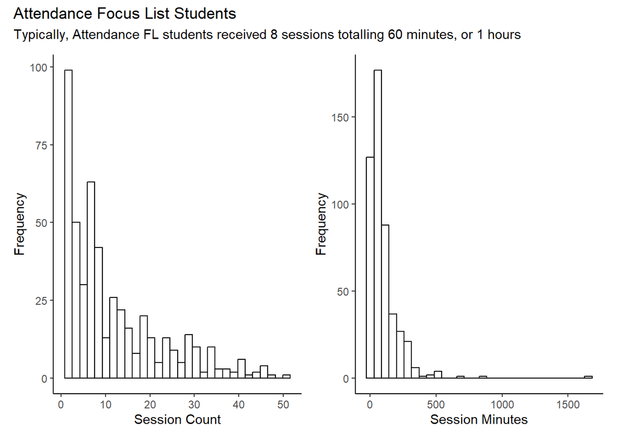

## What Is The ADA Growth For Students In 3 Weeks After Being Enrolled On an Attendance Focus List?

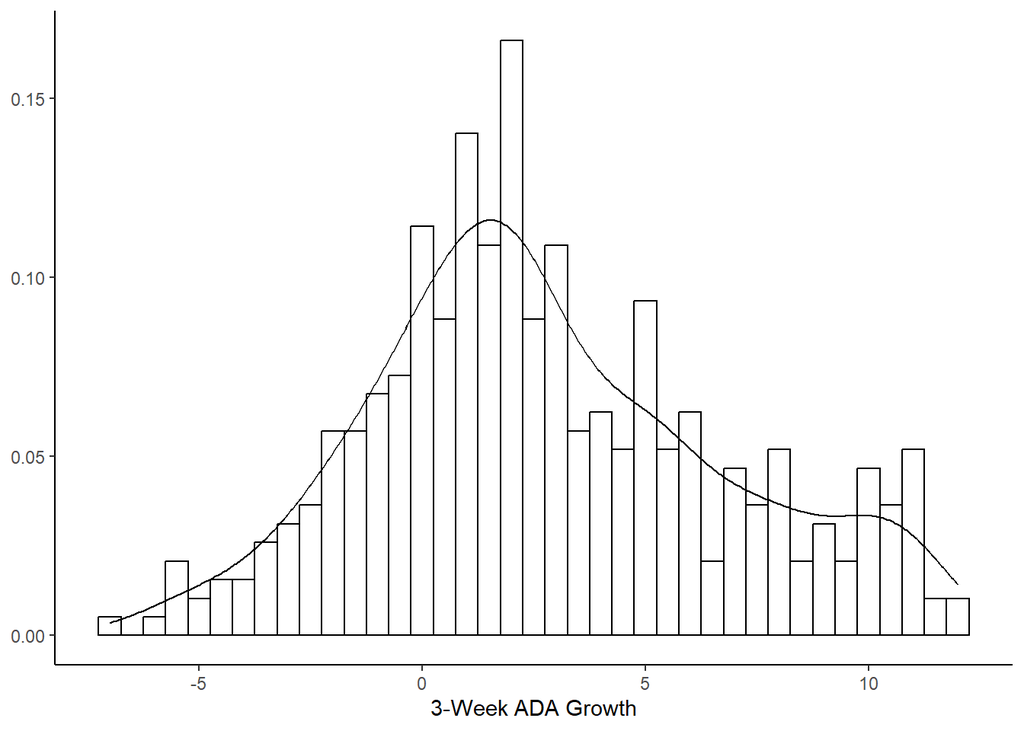

```
##
##  Shapiro-Wilk normality test
##
## data:  ada_match$ada_growth
## W = 0.97711, p-value = 8.888e-06
```

```
##
##  Wilcoxon signed rank test with continuity correction
##
## data:  ada_match$ada_growth
## V = 56070, p-value < 2.2e-16
## alternative hypothesis: true location is not equal to 0
```

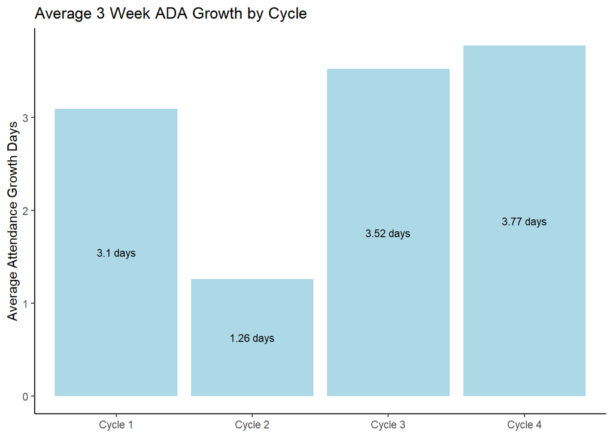

On average, Attendance focus list students improved their attendance for **2.78** days, or by **18.55%** in 3 weeks after being enrolled. Typically, Attendance focus list students improved their attendance by **2** days, or by **13.33%** in 3 weeks after being enrolled.

## ADA Growth by Initial ADA In 3 Weeks

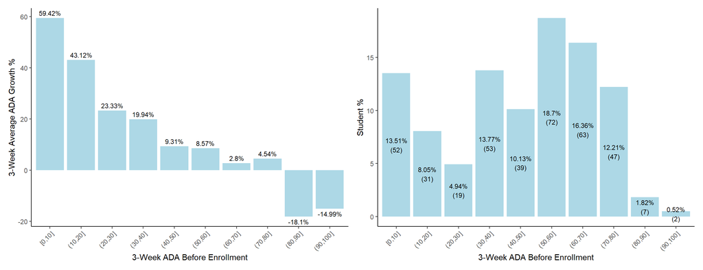

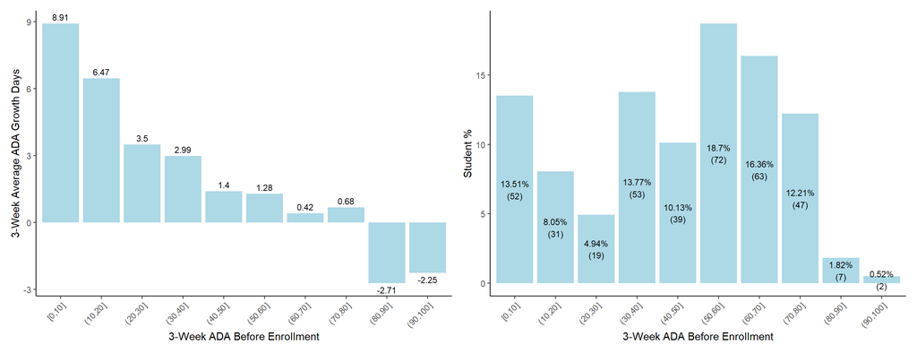

## What Is The ADA Growth For Students In 3 Weeks After Being Enrolled On an Attendance Focus List in 2022?

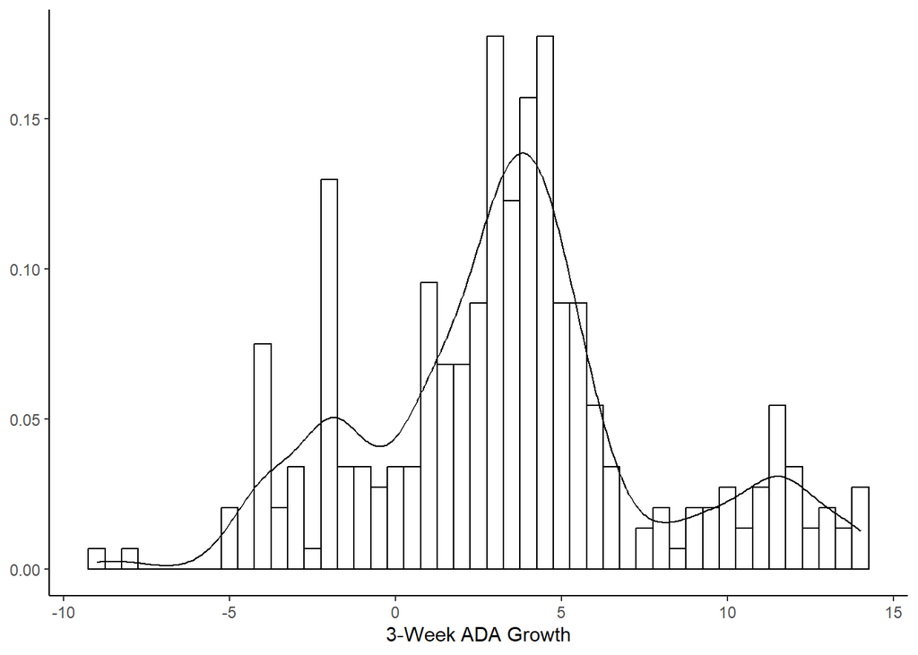

On average, Attendance focus list students improved their attendance for **3.42** days, or by **22.79%** in 3 weeks after being enrolled. Typically, Attendance focus list students improved their attendance by **3.5** days, or by **23.33%** in 3 weeks after being enrolled.

## What Is The ADA Growth For Students In 3 Weeks After Being Enrolled On an Attendance Focus List in 2021?

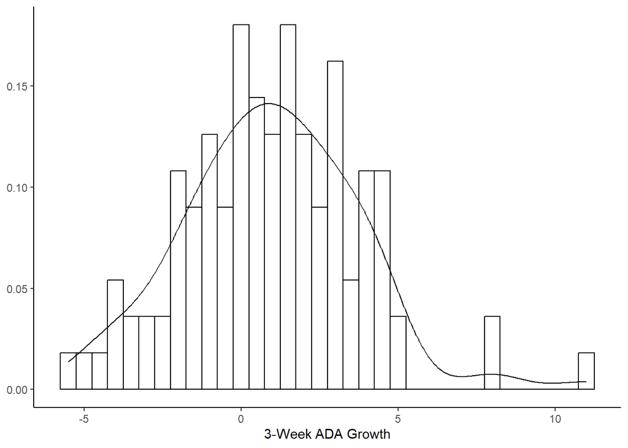

On average, Attendance focus list students improved their attendance for **0.94** days, or by **6.25%** in 3 weeks after being enrolled. Typically, Attendance focus list students improved their attendance by **1** days, or by **6.67%** in 3 weeks after being enrolled.

## What Is The ADA Growth For Students In 3 Weeks After Being Enrolled On an Attendance Focus List in 2020?

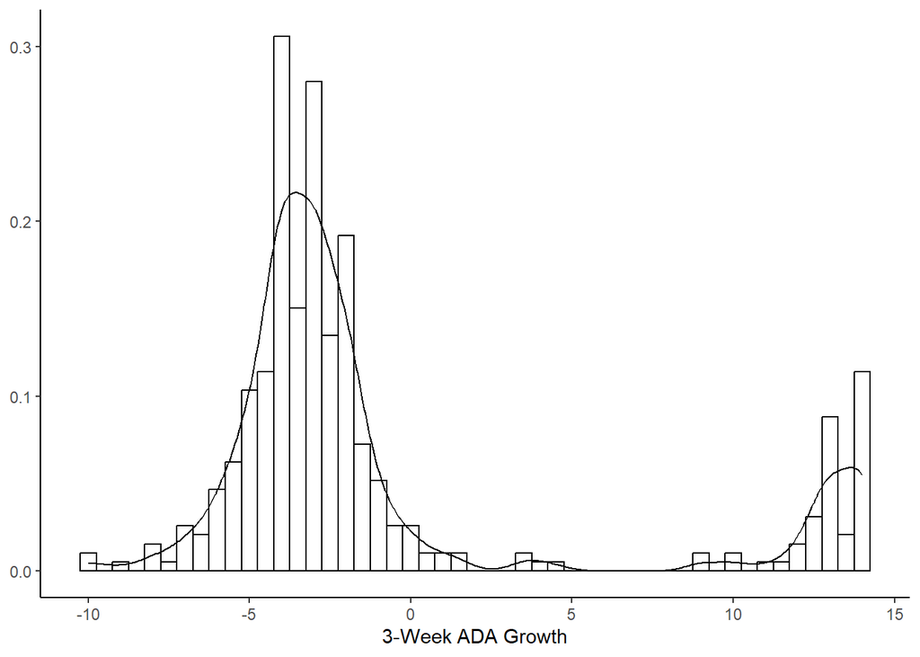

On average, Attendance focus list students improved their attendance for **-0.87** days, or by **-5.81%** in 3 weeks after being enrolled. Typically, Attendance focus list students improved their attendance by **-3** days, or by **-20%** in 3 weeks after being enrolled.

## Typical Attendance During Consecutive Weeks of Dosage

This analysis looks at the typical district present days during the consecutive weeks served. Assuming each week is a whole school week, the ADA % is calculated by dividing present days with number of consecutive weeks served times 5. If a student has multiple similar consecutive weeks served, only the ADA on the latest consecutive week is included in the analysis

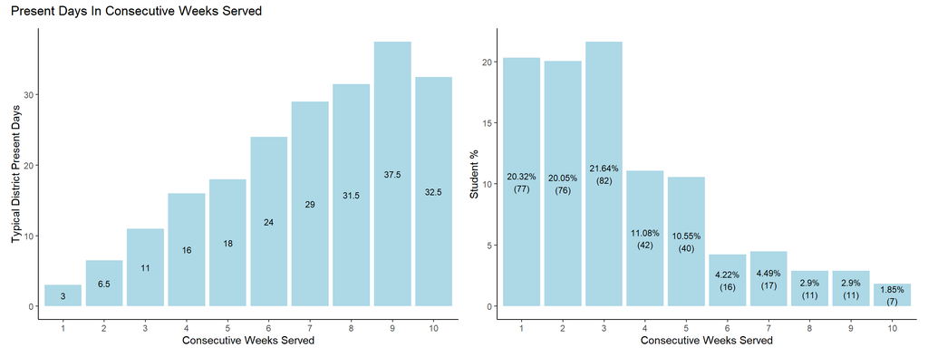

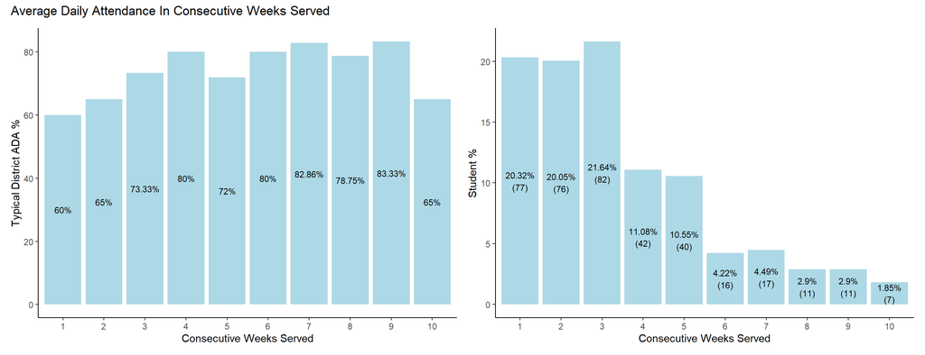

## ADA by Cycle

This analysis looks at the district ADA movement in a graph with vertical lines representing each quarter end dates

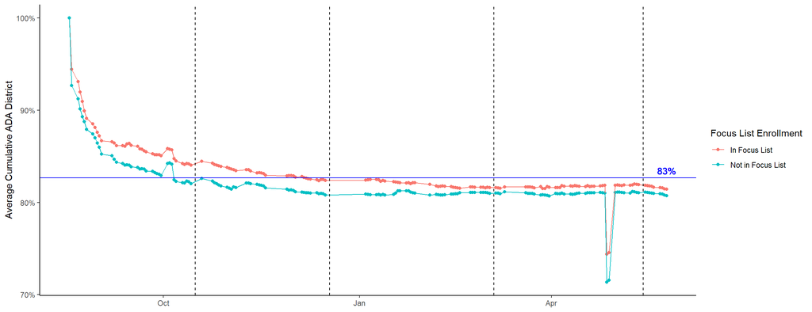

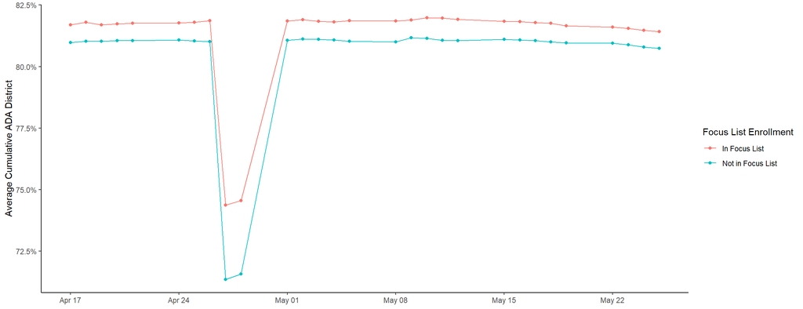

Now, looking at ADA by cycle, look at students enrolled before end of cycle, and look at their ADA movement

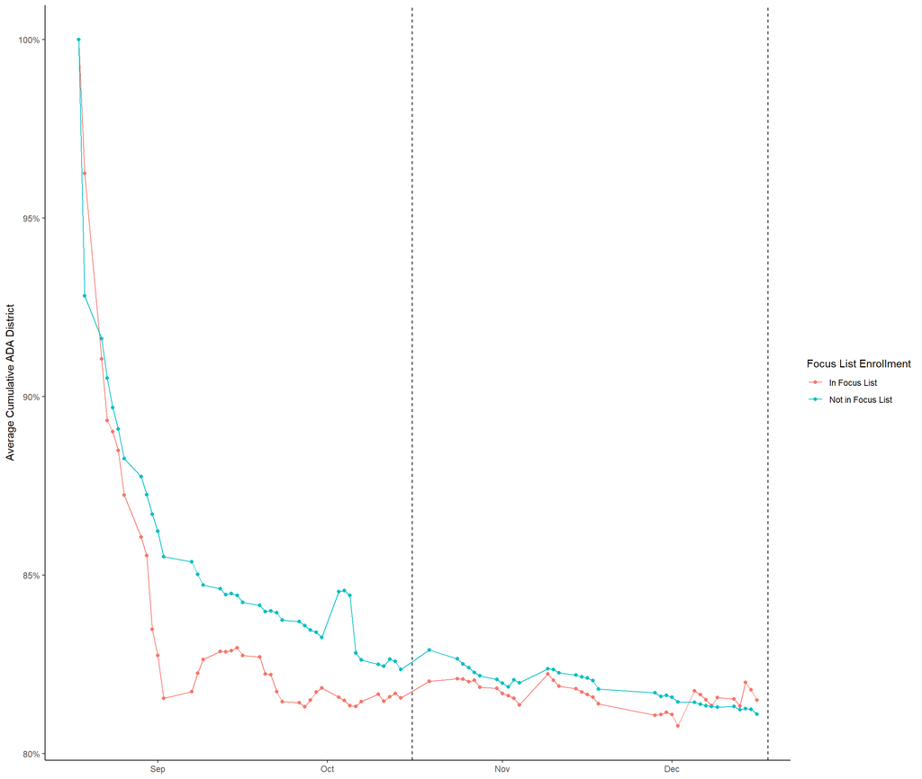

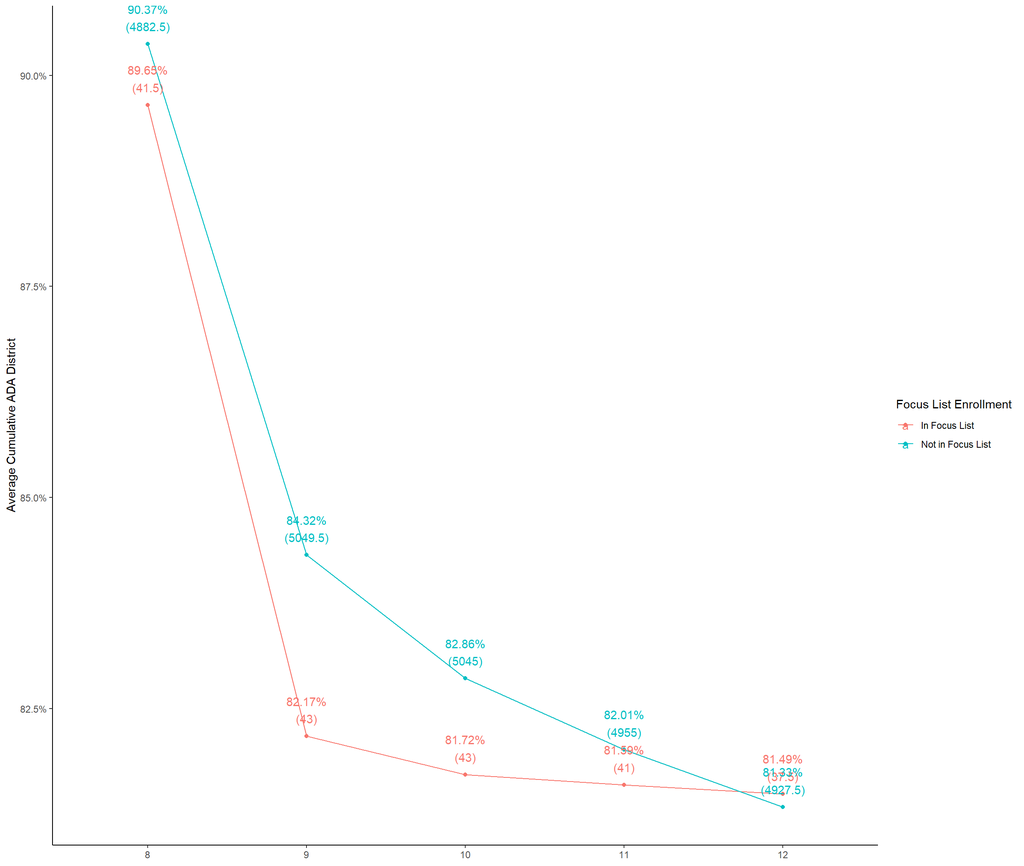

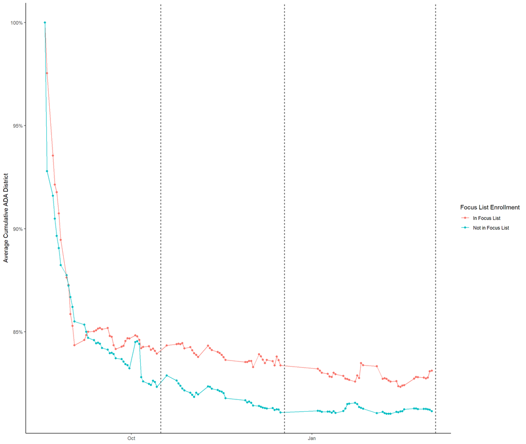

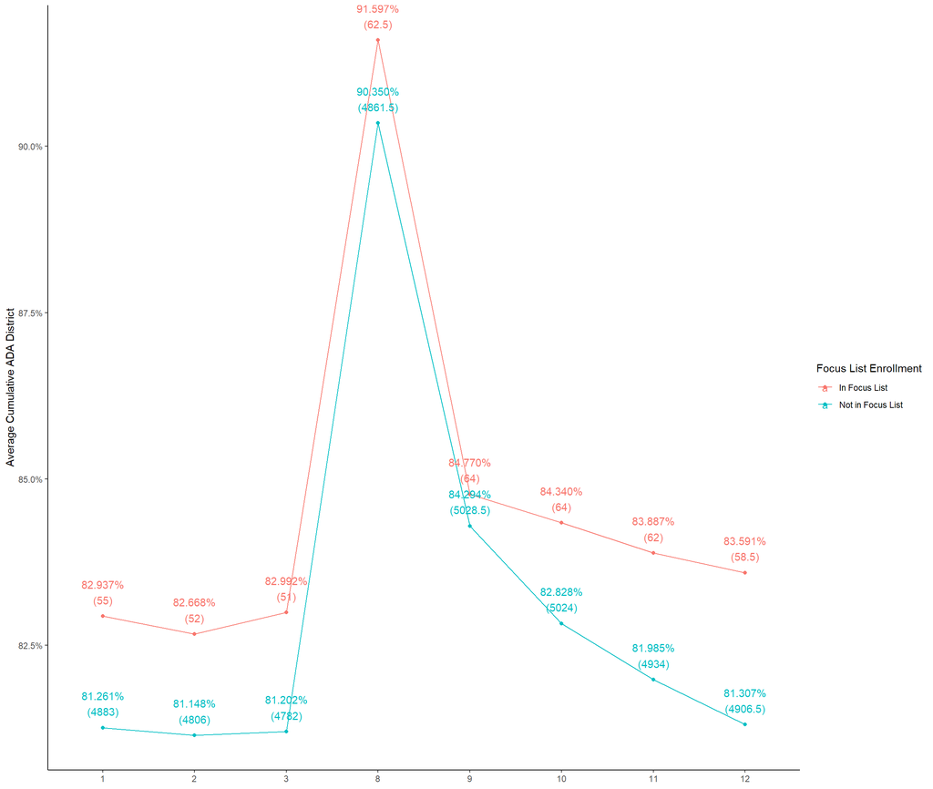

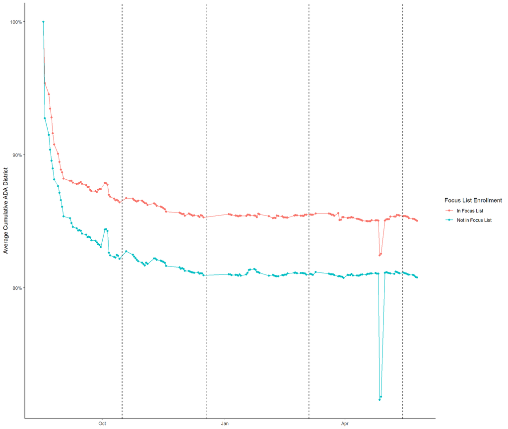

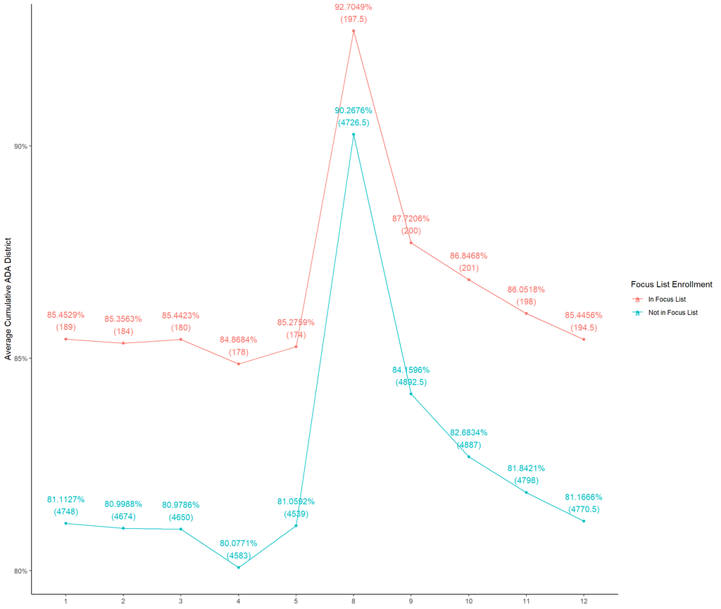

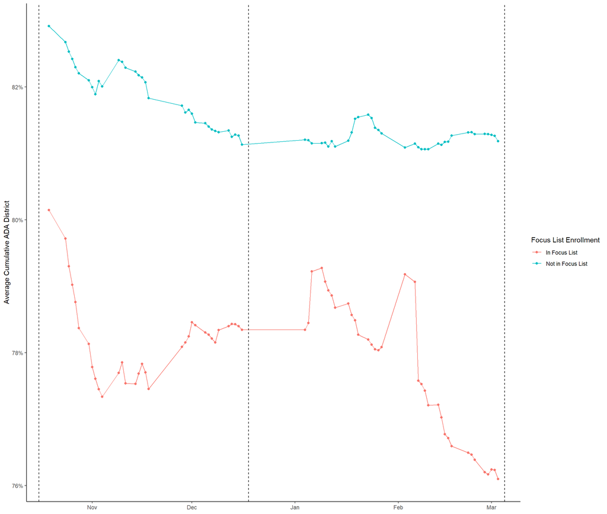

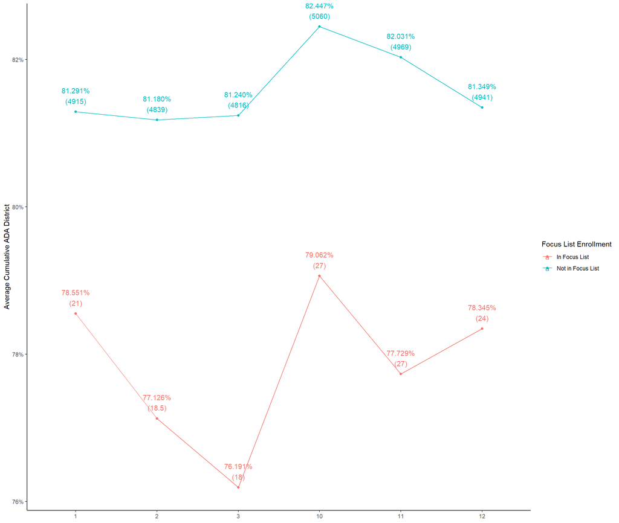

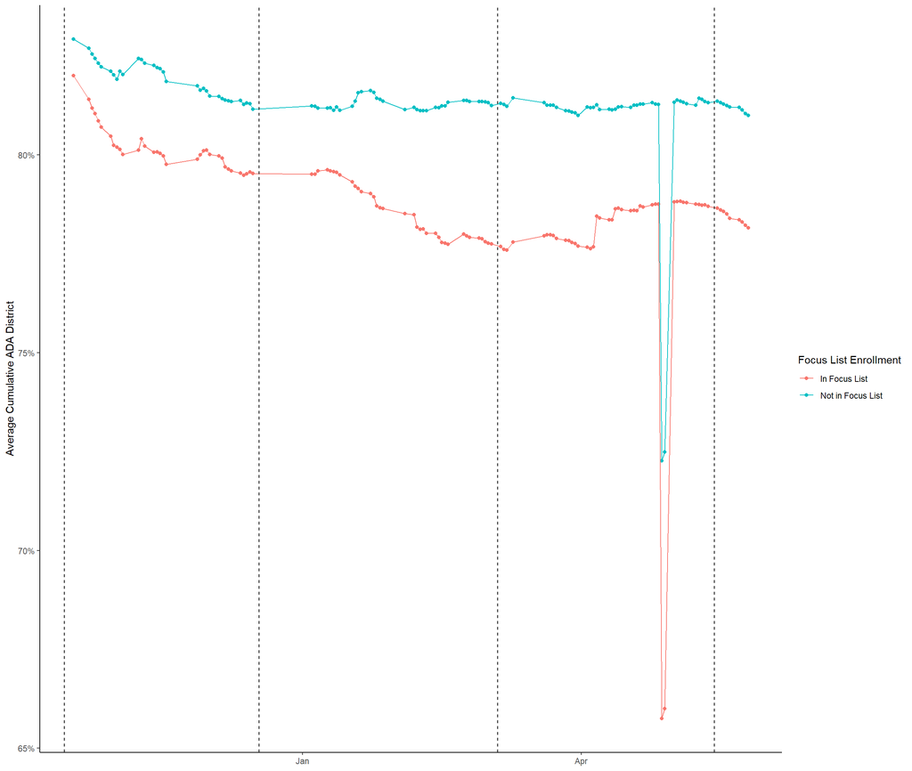

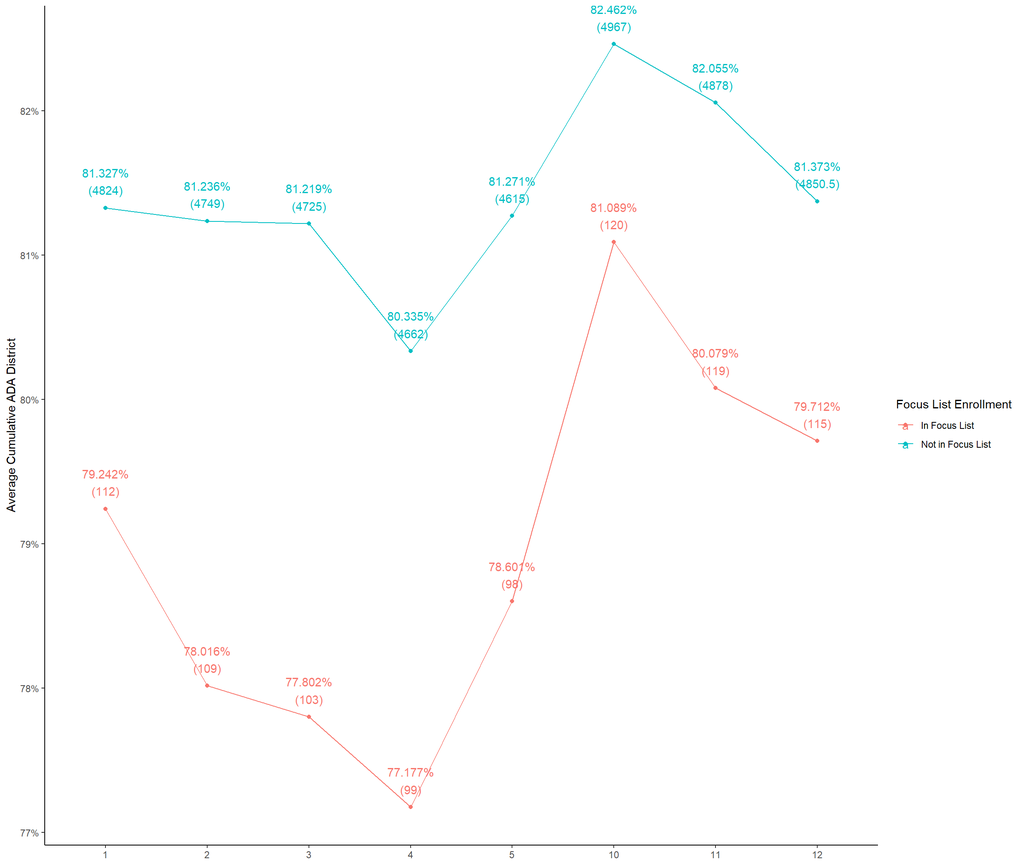

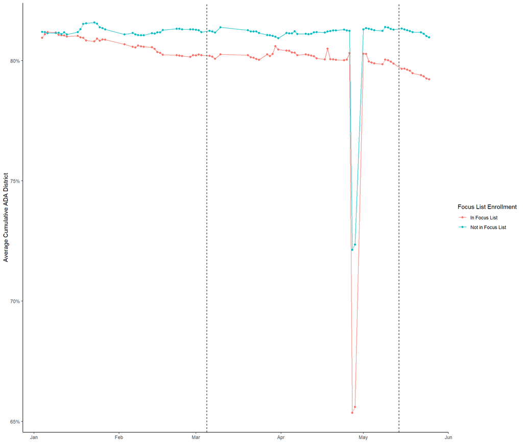

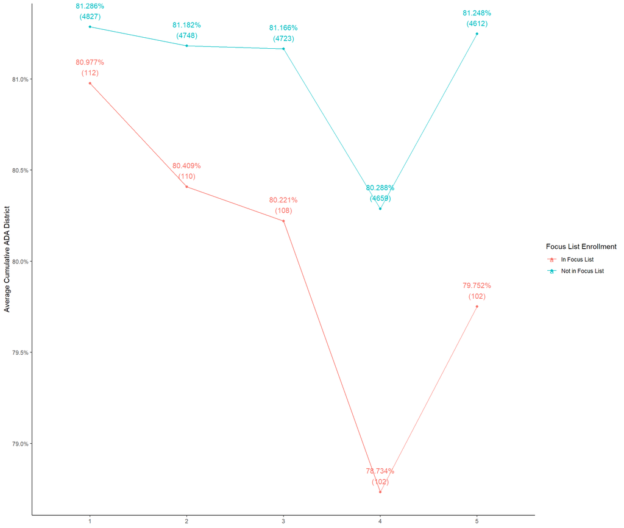

## ADA Growth by Post-ADA

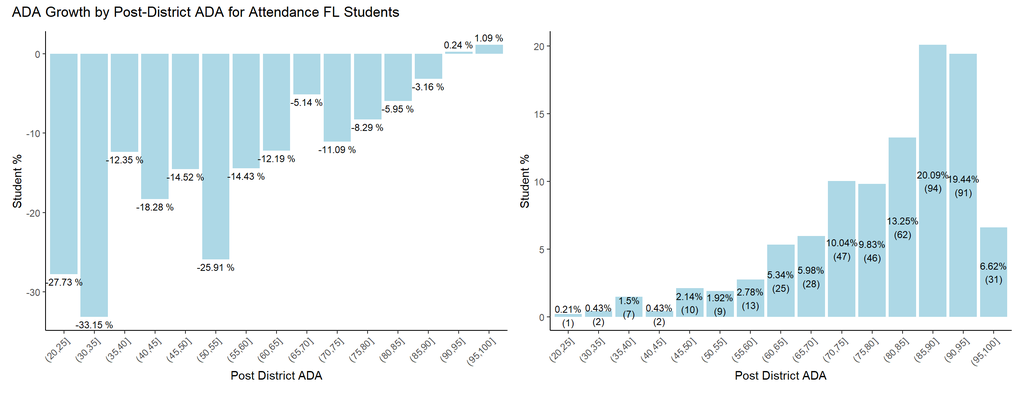

## ADA Growth by Pre-ADA

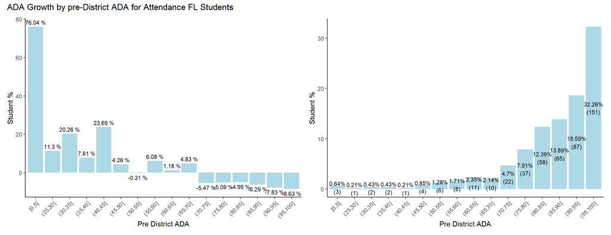